# Métodos Numéricos Aplicados a Finanças — Turma 2025

Aula 09

Prof. Frega PPGOLD/Universidade Federal do Paraná

06/05/2025

```r
library(magrittr)
.sgouttype = ifelse(!is.null(knitr::opts_knit$get("out.format")), "html", "text")
.stargazertype = .sgouttype
source("https://raw.githubusercontent.com/jrfrega/2025/refs/heads/main/mhist.R")
library(stargazer)
library(tseries) # for ADF unit root tests
library(dynlm)
library(nlWaldTest) # for the `nlWaldtest()` function
library(lmtest) #for `coeftest()` and `bptest()`.
library(broom) #for `glance(`) and `tidy()`
library(PoEdata) #for PoE4 datasets
library(car) #for `hccm()` robust standard errors
library(sandwich)
library(knitr) #for kable()
library(forecast)
```

# 1 Estacionariedade e não-estacionariedade

## 1.1 Série estacionária

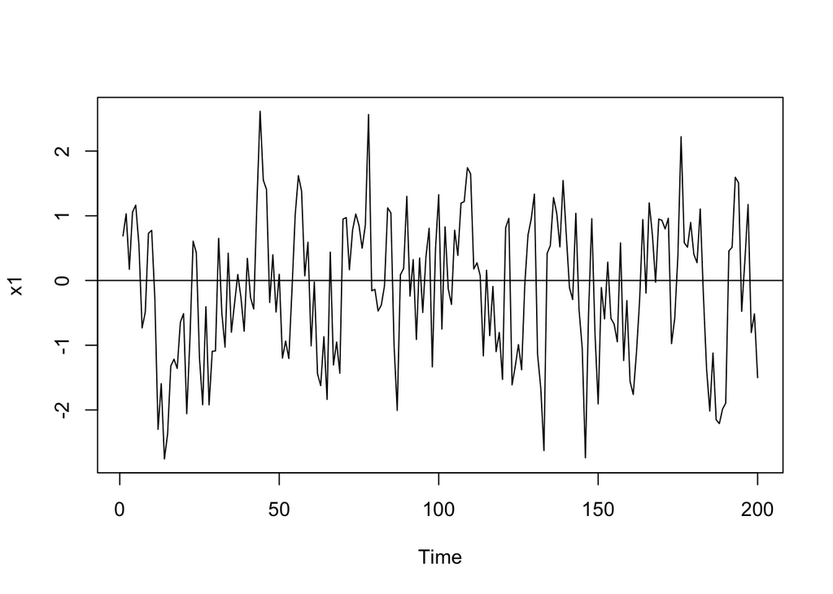

```r
set.seed(10)
# Gerando uma série de 200 observações com autocorrelação AR(1) = 0.4
# A série é autocorrelacionada e estacionária
x1 = arima.sim(list(ar = c(0.4, 0, 0)), 200)
plot.ts(x1); abline(h = 0)
```

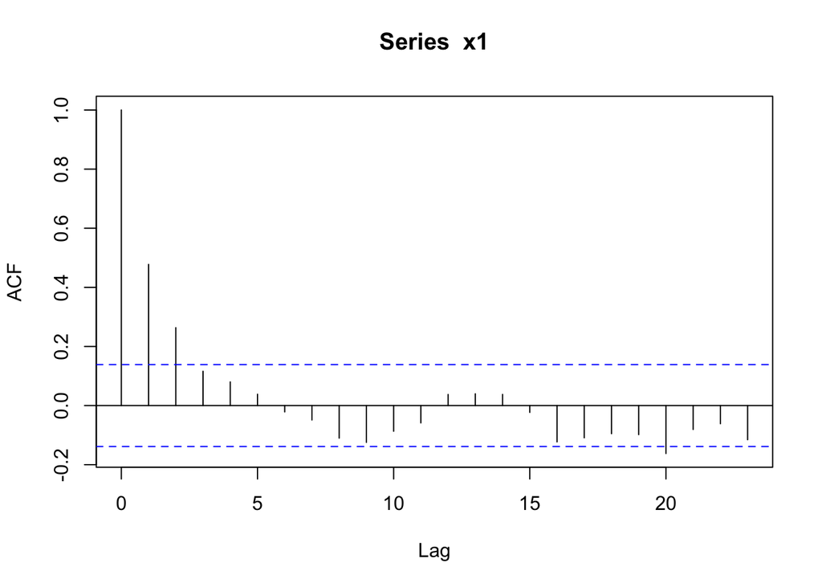

```r
acf(x1)
```

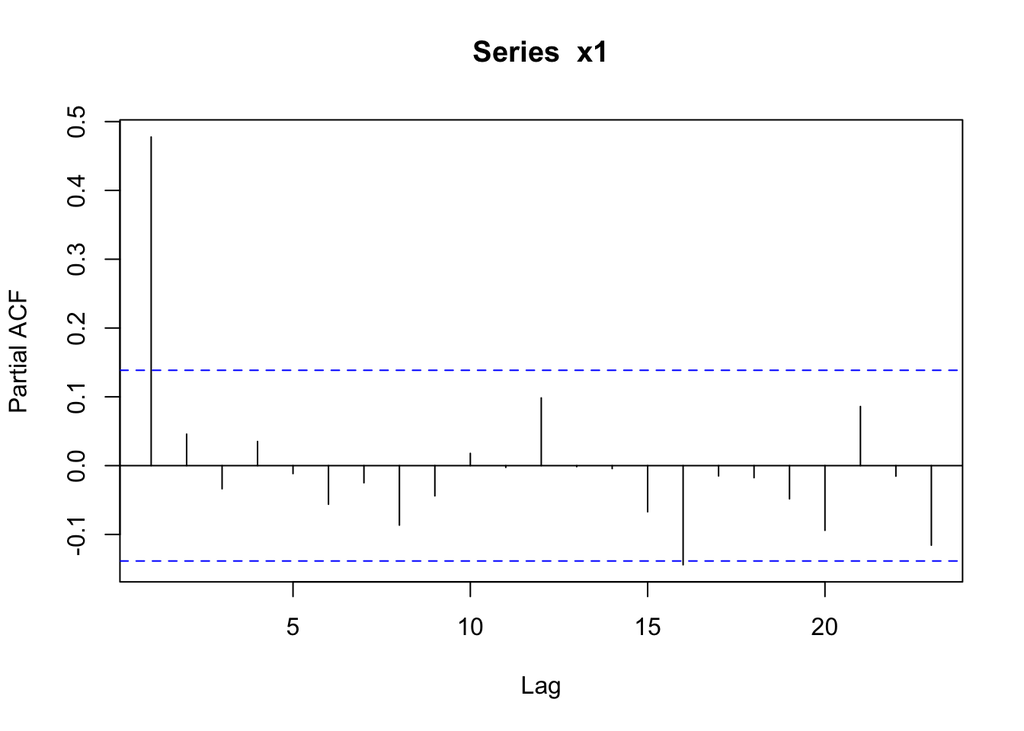

```r
pacf(x1)
```

```r
set.seed(10)
# Gerando uma série de 200 observações com autocorrelação AR(1) = 0
# A série é estacionária
x2 = arima.sim(list(ar = c(0.0, 0, 0)), 200)
```

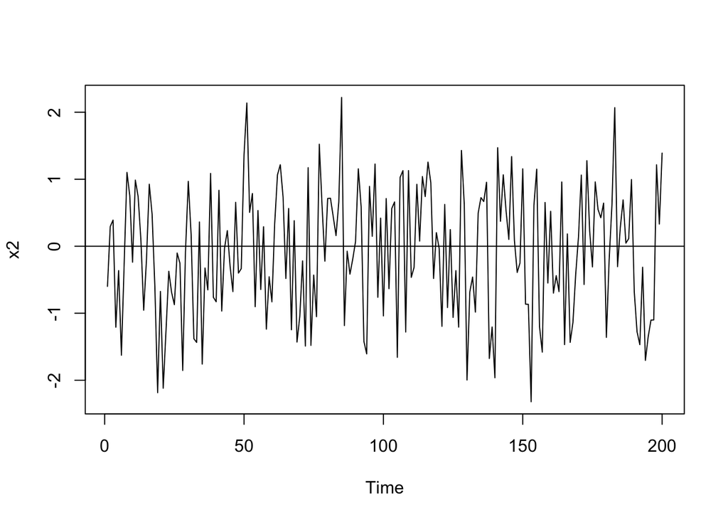

```r
plot.ts(x2); abline(h = 0)
```

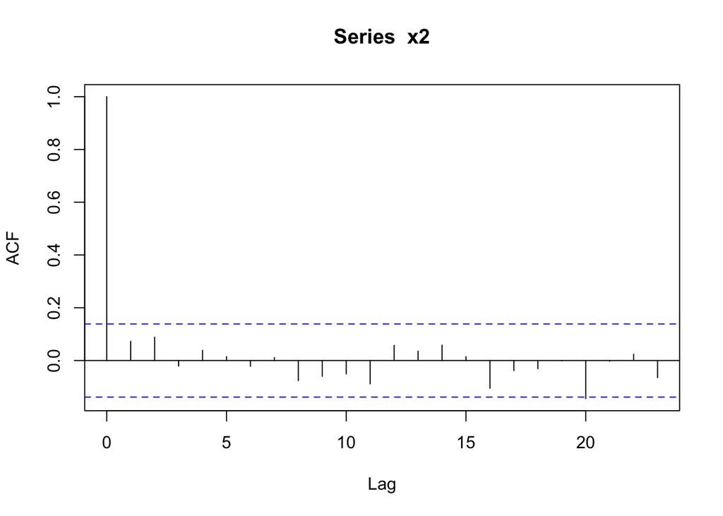

```r
acf(x2)
```

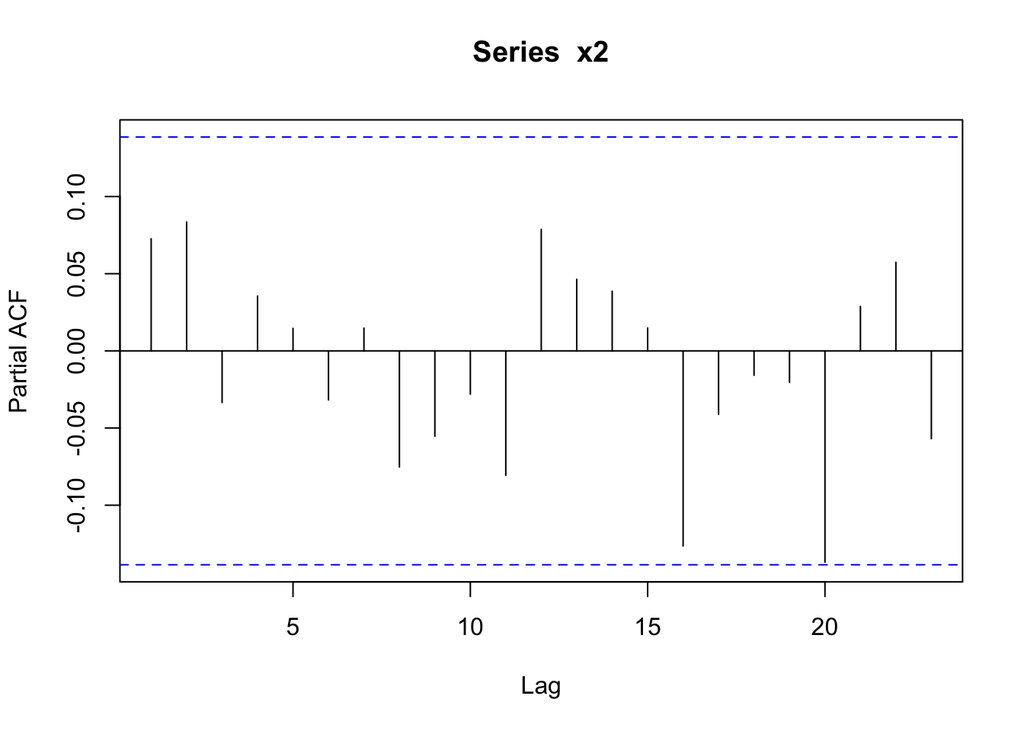

```r
pacf(x2)
```

## Série Integrada - Não estacionária

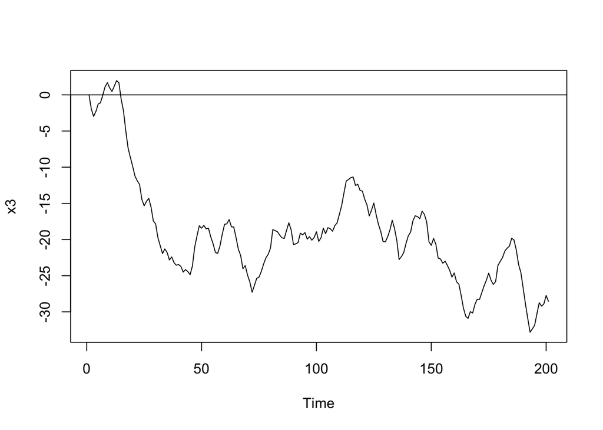

```r
set.seed(10)
# Gerando uma série de 200 observações com autocorrelação AR(1) = 0.4
# A série é autoregressiva e não-estacionária
x3 = arima.sim(list(ar = 0.4, order = c(1, 1, 0)), 200)
plot.ts(x3); abline(h = 0)
```

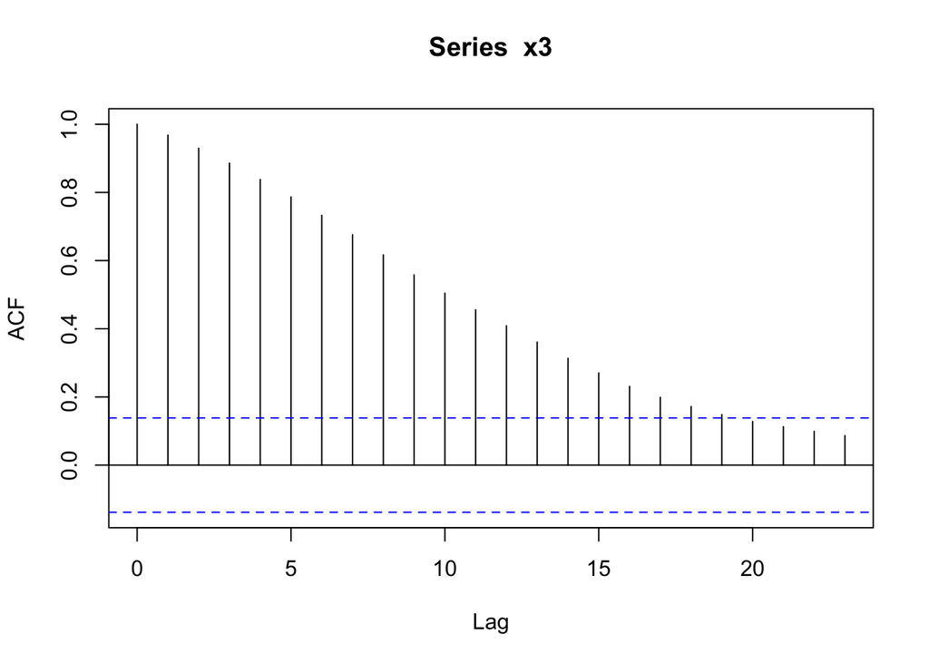

```r
acf(x3)
```

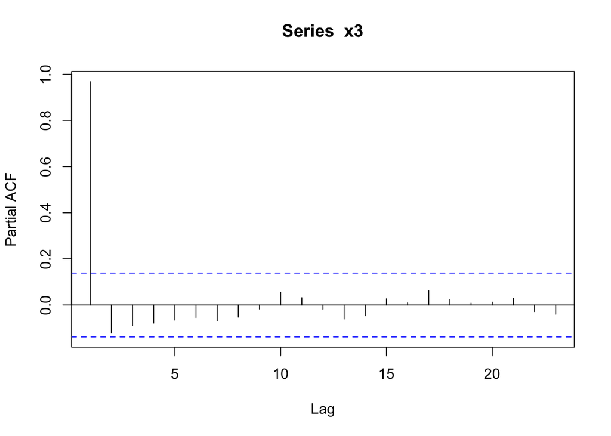

```r
pacf(x3)
```

$$\text{diff}(x_t) = x_t-x_{t-1}$$

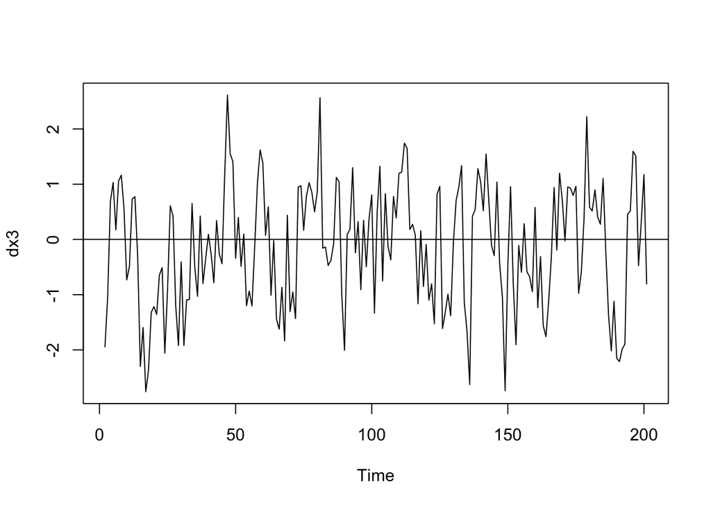

```r
x3 %>% diff -> dx3
plot.ts(dx3); abline(h = 0)
```

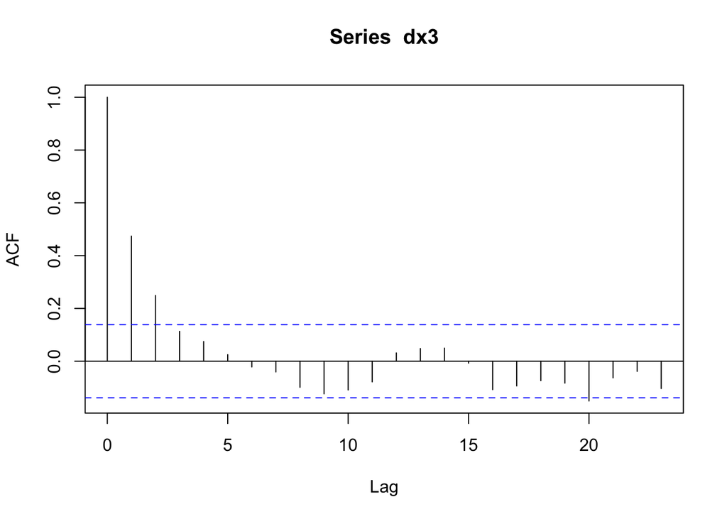

```r
acf(dx3)
```

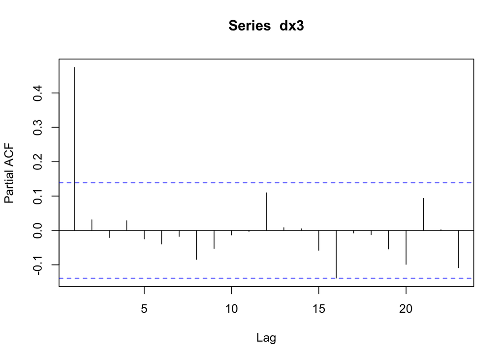

```r
pacf(dx3)
```

```r
# Série autocorrelacionada e estacionária
dynlm(x1~L(x1, 1)) %>% summary
```

```
##
## Time series regression with "ts" data:
## Start = 2, End = 200
##
## Call:
## dynlm(formula = x1 ~ L(x1, 1))
##
## Residuals:
##      Min       1Q   Median       3Q      Max
## -2.15684 -0.76995  0.04031  0.73315  2.22946
##
## Coefficients:
##             Estimate Std. Error t value Pr(>|t|)
## (Intercept) -0.07894    0.06872  -1.149    0.252
## L(x1, 1)     0.48144    0.06265   7.685 7.08e-13 ***
## ---
## Signif. codes:  0 '***' 0.001 '**' 0.01 '*' 0.05 '.' 0.1 ' ' 1
##
## Residual standard error: 0.9624 on 197 degrees of freedom
## Multiple R-squared:  0.2306, Adjusted R-squared:  0.2267
## F-statistic: 59.05 on 1 and 197 DF,  p-value: 7.081e-13
```

```r
# Série estacionária
dynlm(x2~L(x2, 1)) %>% summary
```

```
##
## Time series regression with "ts" data:
## Start = 2, End = 200
##
## Call:
## dynlm(formula = x2 ~ L(x2, 1))
##
## Residuals:
##      Min       1Q   Median       3Q      Max
## -2.17383 -0.74860  0.07225  0.74820  2.25541
##
## Coefficients:
##             Estimate Std. Error t value Pr(>|t|)
## (Intercept) -0.08343    0.06854  -1.217    0.225
## L(x2, 1)     0.07357    0.07144   1.030    0.304
##
## Residual standard error: 0.9616 on 197 degrees of freedom
## Multiple R-squared:  0.005354,   Adjusted R-squared:  0.0003052
## F-statistic:  1.06 on 1 and 197 DF,  p-value: 0.3044
```

```r
# Série autocorrelacionada e não-estacionária
# Vejam o R^2 da regressão: temos algo de muito errado.
dynlm(x3~L(x3, 1)) %>% summary
```

```
##
## Time series regression with "ts" data:
## Start = 2, End = 201
##
## Call:
## dynlm(formula = x3 ~ L(x3, 1))
##
## Residuals:
##      Min       1Q   Median       3Q      Max
## -2.56046 -0.82353  0.05125  0.87277  2.65710
##
## Coefficients:
##             Estimate Std. Error t value Pr(>|t|)
## (Intercept) -0.60032    0.21354  -2.811  0.00543 **
## L(x3, 1)     0.97604    0.01043  93.564  < 2e-16 ***
## ---
## Signif. codes:  0 '***' 0.001 '**' 0.01 '*' 0.05 '.' 0.1 ' ' 1
##
## Residual standard error: 1.086 on 198 degrees of freedom
## Multiple R-squared:  0.9779, Adjusted R-squared:  0.9778
## F-statistic:  8754 on 1 and 198 DF,  p-value: < 2.2e-16
```

```r
# Série autocorrelacionada e estacionária pela primeira diferença
dynlm(dx3~L(dx3, 1)) %>% summary
```

```
##
## Time series regression with "ts" data:
## Start = 3, End = 201
##
## Call:
## dynlm(formula = dx3 ~ L(dx3, 1))
##
## Residuals:
##      Min       1Q   Median       3Q      Max
## -2.17521 -0.75470  0.04664  0.73026  2.22361
##
## Coefficients:
##             Estimate Std. Error t value Pr(>|t|)
## (Intercept) -0.06745    0.06881  -0.980    0.328
## L(dx3, 1)    0.47488    0.06222   7.632 9.71e-13 ***
## ---
## Signif. codes:  0 '***' 0.001 '**' 0.01 '*' 0.05 '.' 0.1 ' ' 1
##
## Residual standard error: 0.9629 on 197 degrees of freedom
## Multiple R-squared:  0.2282, Adjusted R-squared:  0.2243
## F-statistic: 58.25 on 1 and 197 DF,  p-value: 9.711e-13
```

## 1.2 Integrando séries

$$\text{cumsum}(x_t) = x_t+x_{t-1}$$

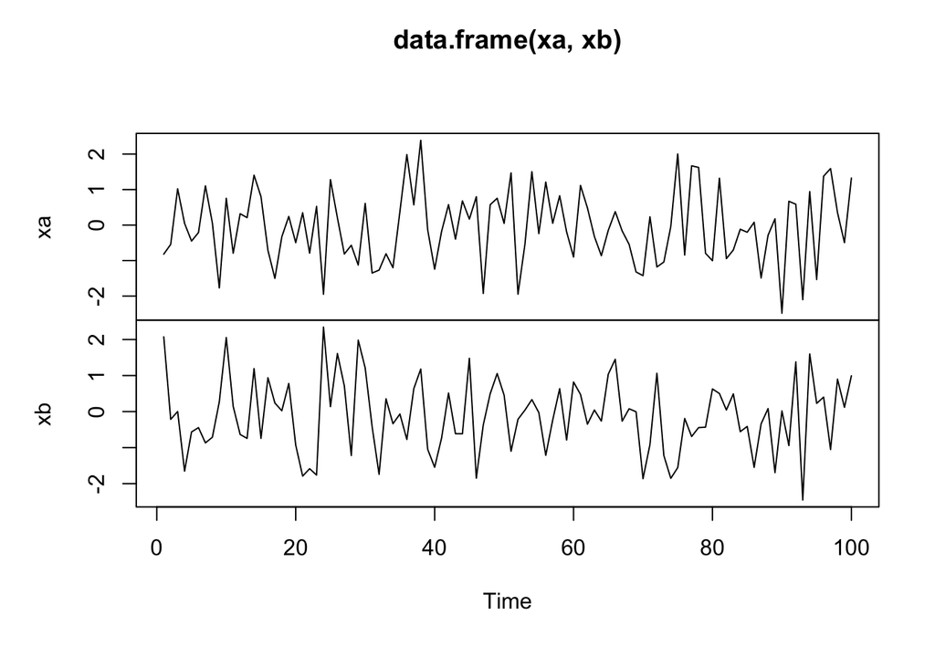

```r
set.seed(131)
xa = rnorm(100)
xb = rnorm(100)
plot.ts(data.frame(xa, xb))
```

```r
cor(xa, xb)
```

```
## [1] 0.03314194
```

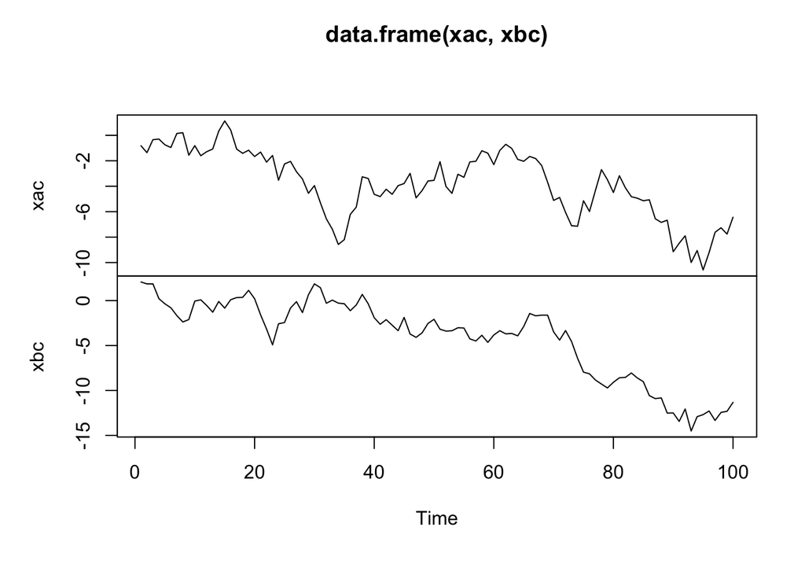

```r
# Integração de primeira ordem
xac = cumsum(xa)
xbc = cumsum(xb)
plot.ts(data.frame(xac, xbc))
```

```r
cor(xac, xbc)
```

```
## [1] 0.6489197
```

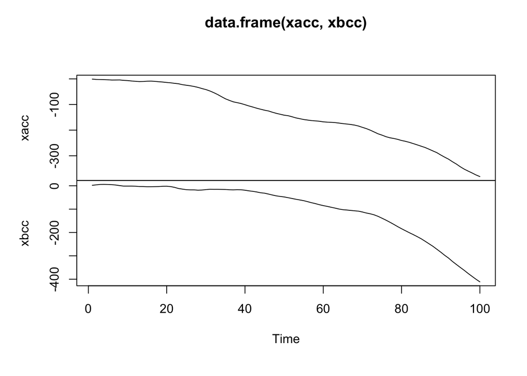

```r
# Integração de segunda ordem
xacc = cumsum(xac)
xbcc = cumsum(xbc)
plot.ts(data.frame(xacc, xbcc))
```

```r
cor(xacc, xbcc)
```

```
## [1] 0.9445553
```

Se não controlarmos a não-estacionariedade, correremos o risco de detectar correlações (e regressões) espúrias, ou seja, inexistentes na realidade.

# 2 Chapter 12 Time Series: Nonstationarity

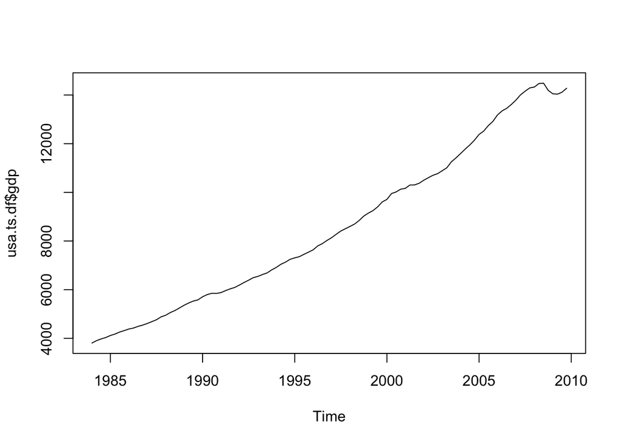

```r
data("usa", package="PoEdata")
usa.ts <- ts(usa, start=c(1984,1), end=c(2009,4),
               frequency=4)
Dgdp <- diff(usa.ts[,1])
Dinf <- diff(usa.ts[,"inf"])
Df <- diff(usa.ts[,"f"])
Db <- diff(usa.ts[,"b"])
usa.ts.df <- ts.union(gdp=usa.ts[,1], # package tseries
                      inf=usa.ts[,2],
                      f=usa.ts[,3],
                      b=usa.ts[,4],
                      Dgdp,Dinf,Df,Db,
                      dframe=TRUE)

plot(usa.ts.df$gdp)
```

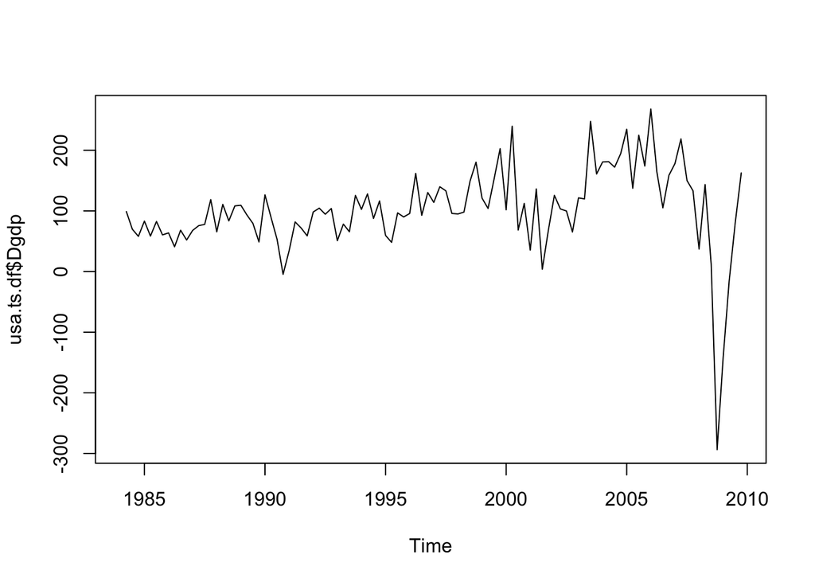

```r
plot(usa.ts.df$Dgdp)
```

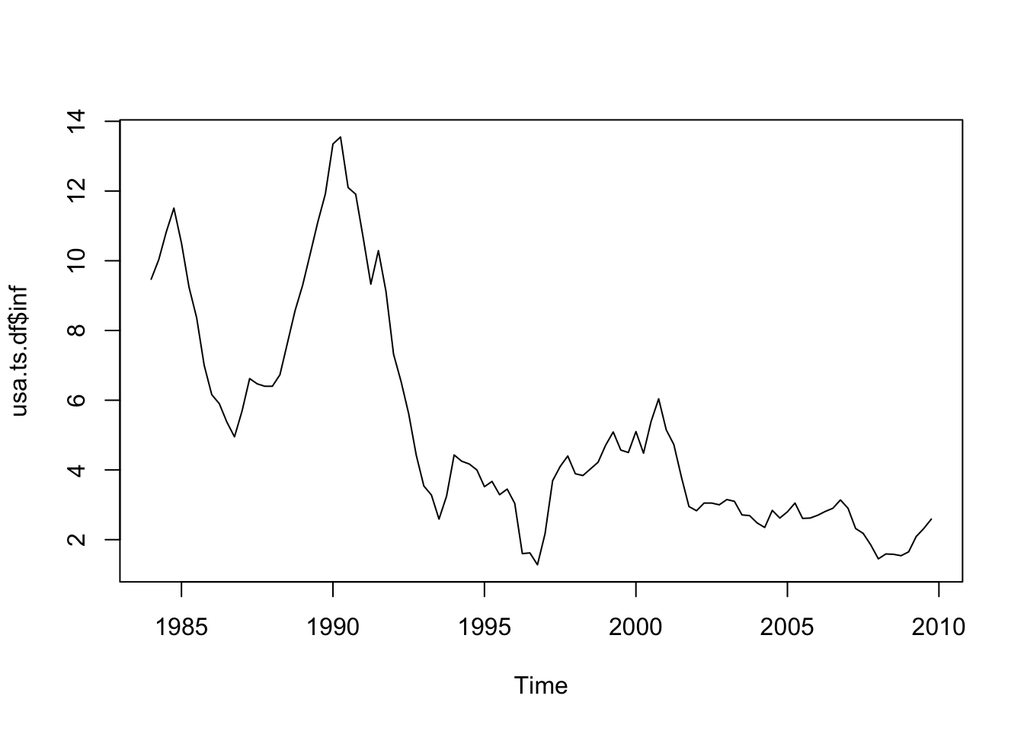

```r
plot(usa.ts.df$inf)
```

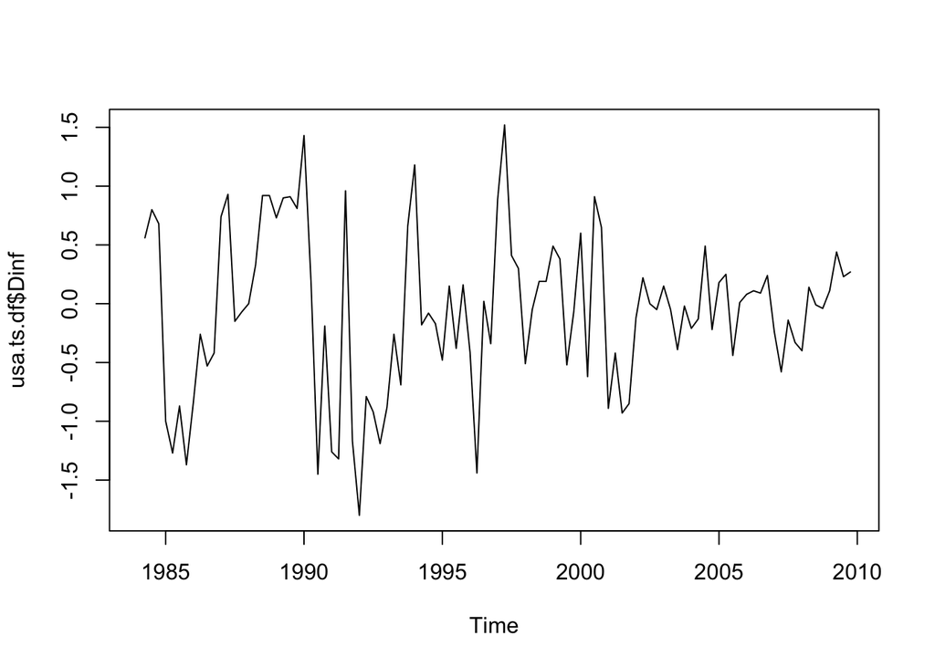

```r
plot(usa.ts.df$Dinf)
```

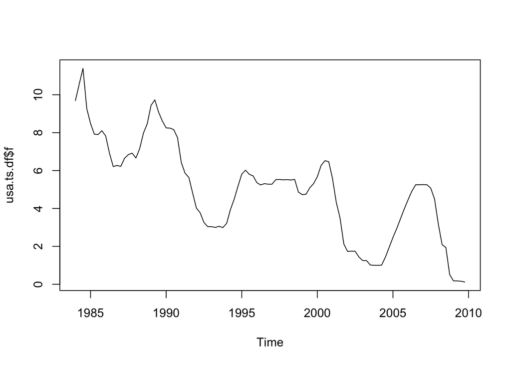

```r
plot(usa.ts.df$f)
```

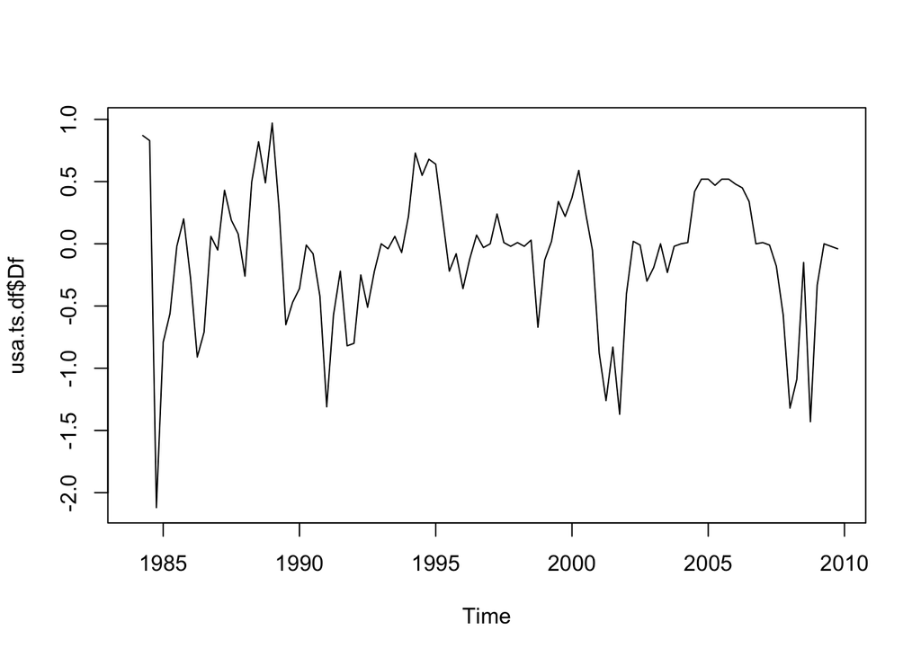

```r
plot(usa.ts.df$Df)
```

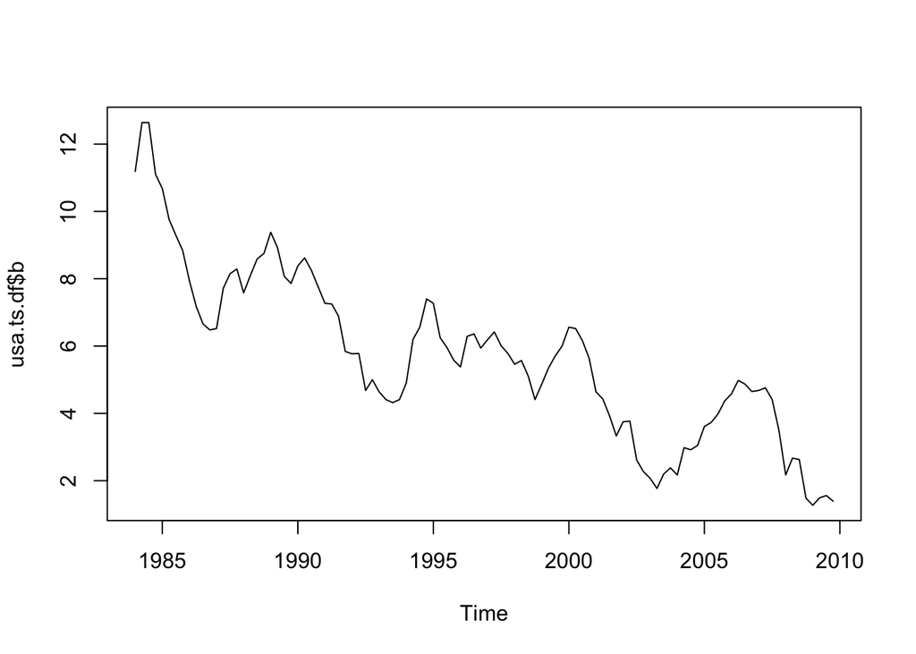

```r
plot(usa.ts.df$b)
```

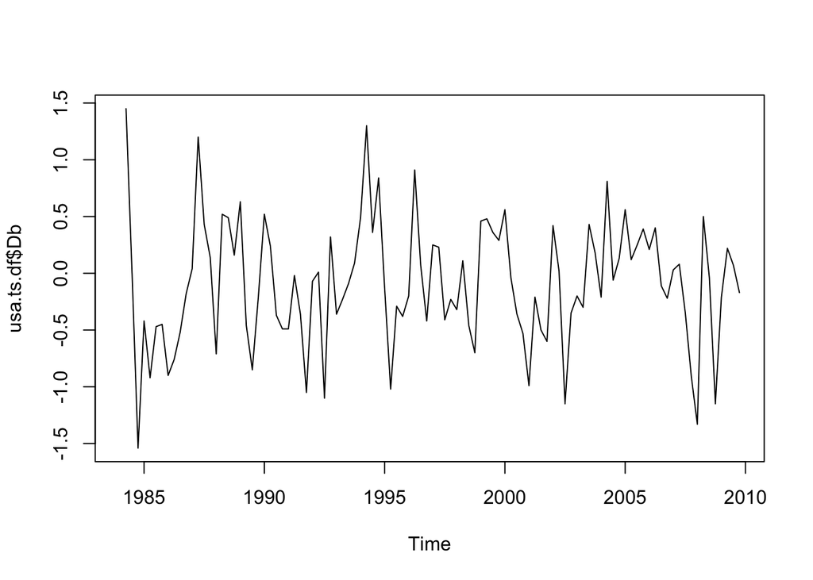

```r
plot(usa.ts.df$Db)
```

As séries que estacionam com a primeira diferença são classificadas como I(1), ou seja, integradas de ordem 1. No caso acima, todas as séries parecem ser I(1), ou seja, estacionaram na primeira diferença.

ARIMA

AR - AutoRegressive I - Integrated MA - Moving average

## 2.1 12.1 AR(1), the First-Order Autoregressive Model

$$y_t = \rho\ y_{t-1} + \nu_t\quad,\quad |\rho|<1$$

# 3 12.3 Unit Root Tests for Stationarity

O teste tem esse nome porque pretende descobrir a presença de uma raiz unitária no processo autoregressivo, ou seja, o processo tente a se tornar um passeio aleatório. $(\rho = 1)$

## 3.1 Teste de Dickey-Fuller

```r
# teste Advanced Dickey-Fuller
# Default: H0: a série é não-estacionária (existe uma raiz unitária)
# Olhem o p-valor: esta série é estacionária
adf.test(x1)
```

```
##
##  Augmented Dickey-Fuller Test
##
## data:  x1
## Dickey-Fuller = -5.1933, Lag order = 5, p-value = 0.01
## alternative hypothesis: stationary
```

```r
# Olhem o p-valor: esta série é estacionária
adf.test(x2)
```

```
##
##  Augmented Dickey-Fuller Test
##
## data:  x2
## Dickey-Fuller = -5.4449, Lag order = 5, p-value = 0.01
## alternative hypothesis: stationary
```

```r
# Olhem o p-valor: esta série é não-estacionária (aceitei H0)
adf.test(x3)
```

```
##
##  Augmented Dickey-Fuller Test
##
## data:  x3
## Dickey-Fuller = -2.964, Lag order = 5, p-value = 0.1723
## alternative hypothesis: stationary
```

```r
# Olhem o p-valor: esta série é estacionária
adf.test(dx3)
```

```
##
##  Augmented Dickey-Fuller Test
##
## data:  dx3
## Dickey-Fuller = -5.1474, Lag order = 5, p-value = 0.01
## alternative hypothesis: stationary
```

```r
apply(usa.ts.df[2:nrow(usa.ts.df),], 2, adf.test, k = 1)
```

```
## $gdp
##
##  Augmented Dickey-Fuller Test
##
## data:  newX[, i]
## Dickey-Fuller = -2.0607, Lag order = 1, p-value = 0.5515
## alternative hypothesis: stationary
##
##
## $inf
##
##  Augmented Dickey-Fuller Test
##
## data:  newX[, i]
## Dickey-Fuller = -2.77, Lag order = 1, p-value = 0.2574
## alternative hypothesis: stationary
##
##
## $f
##
##  Augmented Dickey-Fuller Test
##
## data:  newX[, i]
## Dickey-Fuller = -3.6547, Lag order = 1, p-value = 0.03168
## alternative hypothesis: stationary
##
##
## $b
##
##  Augmented Dickey-Fuller Test
##
## data:  newX[, i]
## Dickey-Fuller = -4.0525, Lag order = 1, p-value = 0.01
## alternative hypothesis: stationary
##
##
## $Dgdp
##
##  Augmented Dickey-Fuller Test
##
```

[output cut: 15 more lines]

```
##
##  Augmented Dickey-Fuller Test
##
## data:  newX[, i]
## Dickey-Fuller = -5.0835, Lag order = 1, p-value = 0.01
## alternative hypothesis: stationary
##
##
## $Db
##
##  Augmented Dickey-Fuller Test
##
## data:  newX[, i]
## Dickey-Fuller = -6.7126, Lag order = 1, p-value = 0.01
## alternative hypothesis: stationary
```

**IMPORTANTE**

A função `adf.test` da biblioteca `tseries` implementa o teste completo ADF, com constante e tendência. Na biblioteca `fUnitRoots` tem a função `adfTest` que dá o controle completo da regressão de Dickey-Fuller.

$$ct: \Delta y_t = \alpha + \gamma\ y_{t-1} + \lambda\ t + \nu_t\\
c: \Delta y_t = \alpha + \gamma\ y_{t-1} + \nu_t\\
nc: \Delta y_t =\gamma\ y_{t-1} + \nu_t$$

```r
library(fUnitRoots)
adfTest(usa.ts.df$b, 1, "nc") # sem alfa e sem lambda
```

```
##
## Title:
##  Augmented Dickey-Fuller Test
##
## Test Results:
##   PARAMETER:
##     Lag Order: 1
##   STATISTIC:
##     Dickey-Fuller: -2.567
##   P VALUE:
##     0.01136
##
## Description:
##  Tue May  6 22:25:29 2025 by user:
```

```r
adfTest(usa.ts.df$b, 1, "c")  # com alfa e sem lambda
```

```
##
## Title:
##  Augmented Dickey-Fuller Test
##
## Test Results:
##   PARAMETER:
##     Lag Order: 1
##   STATISTIC:
##     Dickey-Fuller: -2.7028
##   P VALUE:
##     0.08015
##
## Description:
##  Tue May  6 22:25:29 2025 by user:
```

```r
adfTest(usa.ts.df$b, 1, "ct") # com alfa e com lambda
```

```
##
## Title:
##  Augmented Dickey-Fuller Test
##
## Test Results:
##   PARAMETER:
##     Lag Order: 1
##   STATISTIC:
##     Dickey-Fuller: -4.0773
##   P VALUE:
##     0.01
##
## Description:
##  Tue May  6 22:25:29 2025 by user:
```

```r
adf.test(usa.ts.df$b, k = 1)  # com alfa e com lambda
```

```
##
##  Augmented Dickey-Fuller Test
##
## data:  usa.ts.df$b
## Dickey-Fuller = -4.0773, Lag order = 1, p-value = 0.01
## alternative hypothesis: stationary
```

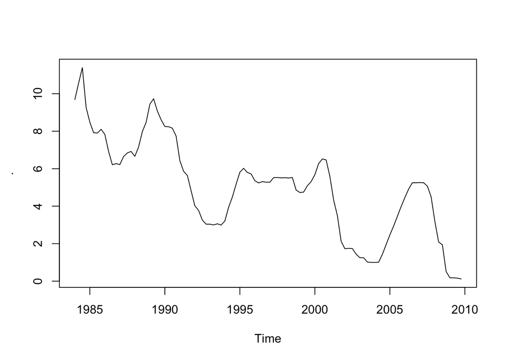

```r
usa.ts.df$f %>% plot.ts
```

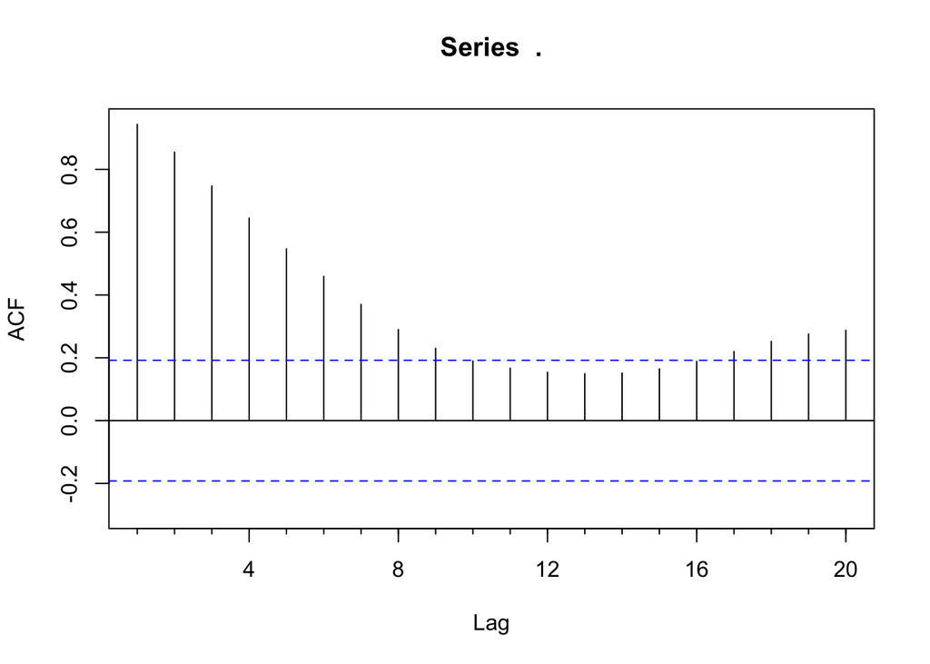

```r
usa.ts.df$f %>% Acf
```

```r
usa.ts.df$f %>% adf.test(k = 10)
```

```
##
##  Augmented Dickey-Fuller Test
##
## data:  .
## Dickey-Fuller = -3.3726, Lag order = 10, p-value = 0.06283
## alternative hypothesis: stationary
```

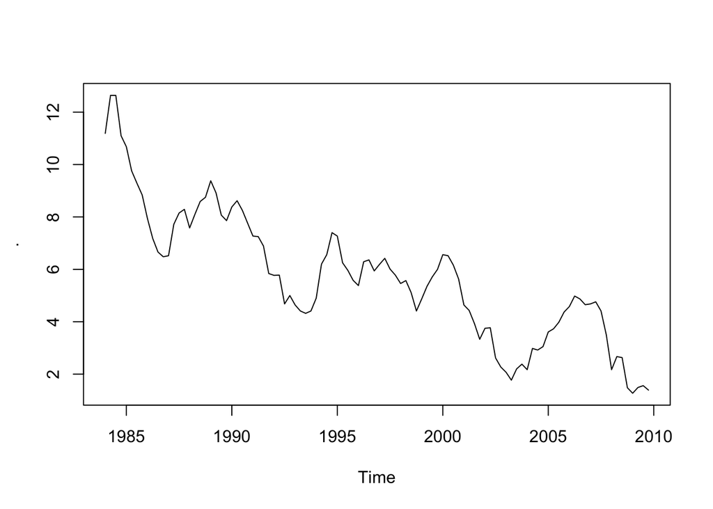

```r
usa.ts.df$b %>% plot.ts
```

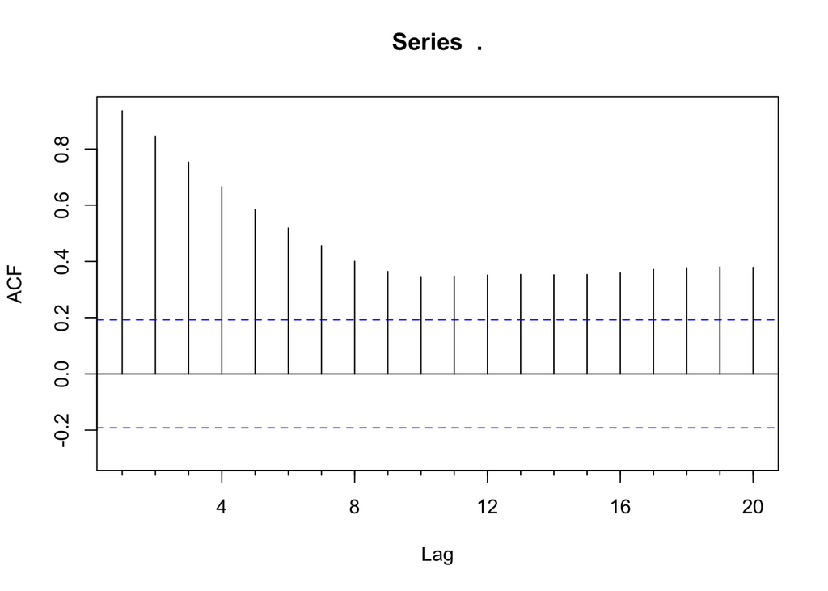

```r
usa.ts.df$b %>% Acf
```

```r
usa.ts.df$f %>% adf.test(k = 20)
```

```
##
##  Augmented Dickey-Fuller Test
##
## data:  .
## Dickey-Fuller = -2.9118, Lag order = 20, p-value = 0.1986
## alternative hypothesis: stationary
```

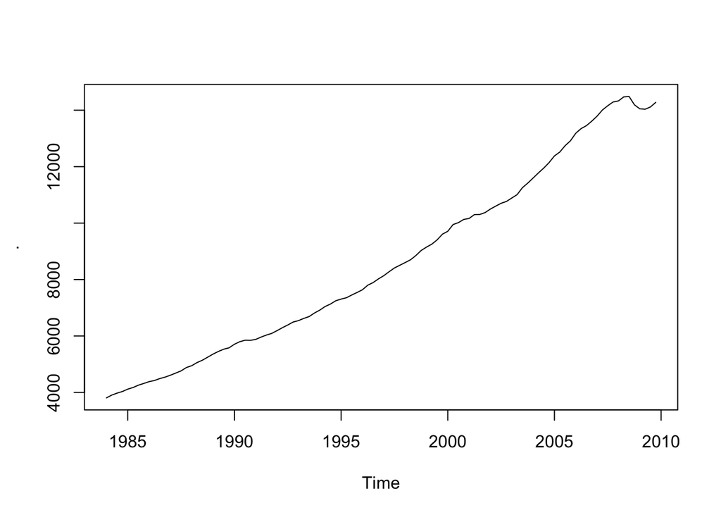

```r
usa.ts.df$gdp %>% plot.ts
```

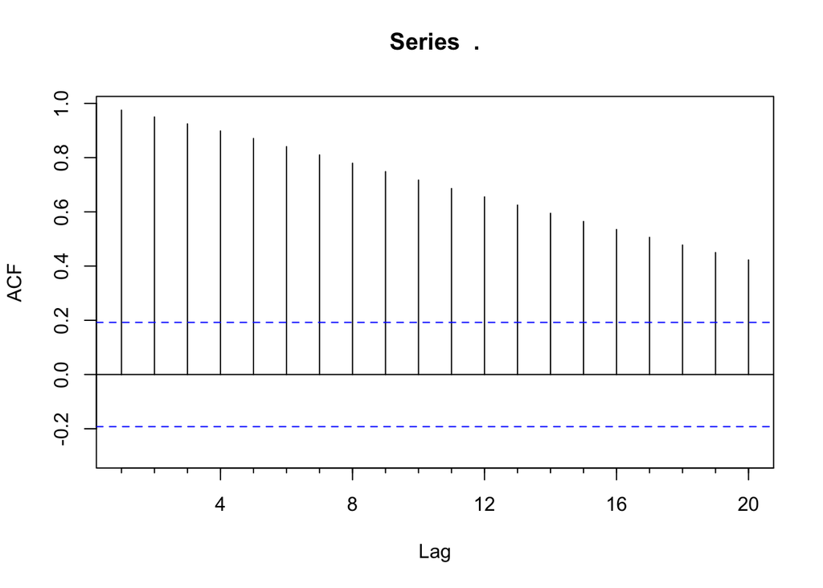

```r
usa.ts.df$gdp %>% Acf -> v
```

```r
usa.ts.df$gdp %>% adf.test(k = 20)
```

```
##
##  Augmented Dickey-Fuller Test
##
## data:  .
## Dickey-Fuller = -0.41659, Lag order = 20, p-value = 0.984
## alternative hypothesis: stationary
```

```r
adf.test(usa.ts.df$gdp)
```

```
##
##  Augmented Dickey-Fuller Test
##
## data:  usa.ts.df$gdp
## Dickey-Fuller = -2.2295, Lag order = 4, p-value = 0.4815
## alternative hypothesis: stationary
```

```r
pp.test(usa.ts.df$gdp)
```

```
##
##  Phillips-Perron Unit Root Test
##
## data:  usa.ts.df$gdp
## Dickey-Fuller Z(alpha) = -4.6301, Truncation lag parameter = 4, p-value
## = 0.8483
## alternative hypothesis: stationary
```

```r
# Cuidado: a H0 do KPSS é de ESTACIONARIEDADE (ao contrário do ADF e do PP)
kpss.test(usa.ts.df$gdp)
```

```
##
##  KPSS Test for Level Stationarity
##
## data:  usa.ts.df$gdp
## KPSS Level = 2.1419, Truncation lag parameter = 4, p-value = 0.01
```

```r
# No pacote forecast tem essa função ndiffs
# que pode usar Dickey-Fuller, Phillips-Perron, KPSS
ndiffs(usa.ts.df$gdp)
```

```
## [1] 1
```

```r
ndiffs(usa.ts.df$inf)
```

```
## [1] 1
```

```r
ndiffs(usa.ts.df$f)
```

```
## [1] 1
```

```r
ndiffs(usa.ts.df$b)
```

```
## [1] 1
```

```r
ndiffs(x1)
```

```
## [1] 0
```

```r
ndiffs(x2)
```

```
## [1] 0
```

```r
ndiffs(x3)
```

```
## [1] 1
```

```r
ndiffs(dx3)
```

```
## [1] 0
```

```r
ndiffs(xac)
```

```
## [1] 1
```

```r
ndiffs(xacc)
```

```
## [1] 2
```

```r
ndiffs(xbc)
```

```
## [1] 1
```

```r
ndiffs(xbcc)
```

```
## [1] 2
```

# 4 12.4 Cointegration

Cointegração é o **ÚNICO** procedimento que usa as séries não-estacionárias.

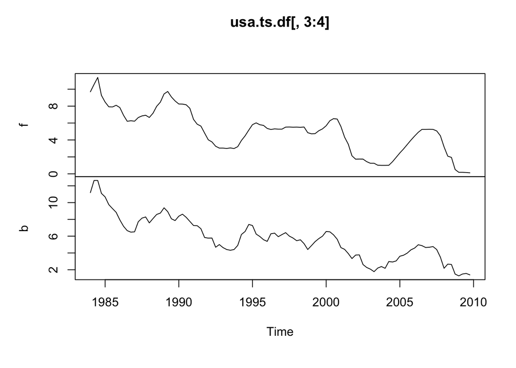

```r
plot.ts(usa.ts.df[,3:4]) # não-estacionárias
```

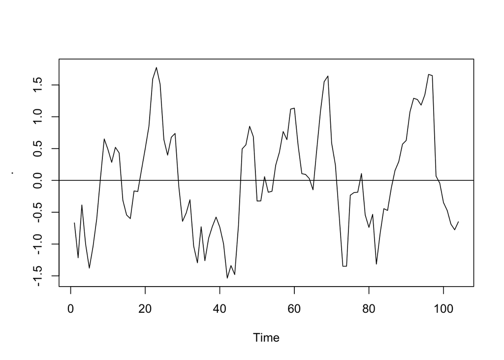

```r
lm(f~b, usa.ts.df) -> m
m$residuals %>% plot.ts; abline(h = 0)
```

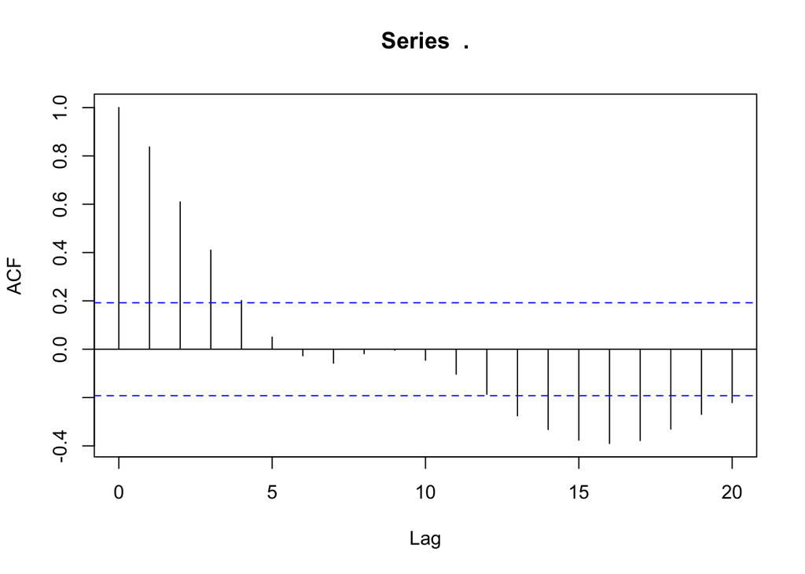

```r
m$residuals %>% acf
```

```r
m$residuals %>% adfTest(lags = 4, type = "nc") # resíduos são estacionários
```

```
##
## Title:
##  Augmented Dickey-Fuller Test
##
## Test Results:
##   PARAMETER:
##     Lag Order: 4
##   STATISTIC:
##     Dickey-Fuller: -3.6625
##   P VALUE:
##     0.01
##
## Description:
##  Tue May  6 22:25:29 2025 by user:
```

```r
m$residuals %>% ndiffs # resíduos são estacionários
```

```
## [1] 0
```

## 4.1 Teste de Phillips-Ouliaris

```r
# H0: não há cointegração
# o teste rejeita fracamente a não-integração, ou seja, as
# séries são fracamente cointegradas
po.test(usa.ts.df[,3:4], demean = FALSE)
```

```
##
##  Phillips-Ouliaris Cointegration Test
##
## data:  usa.ts.df[, 3:4]
## Phillips-Ouliaris standard = -16.817, Truncation lag parameter = 1,
## p-value = 0.04095
```

# 5 12.5 The Error Correction Model

Teste de Johansen da biblioteca `urca`

```r
library(urca)
# teste de cointegração mais rigoroso
urca::ca.jo(usa.ts.df[,4:3], type = "eigen") %>% summary
```

```
##
## ######################
## # Johansen-Procedure #
## ######################
##
## Test type: maximal eigenvalue statistic (lambda max) , with linear trend
##
## Eigenvalues (lambda):
## [1] 0.11594535 0.05544127
##
## Values of teststatistic and critical values of test:
##
##           test 10pct  5pct  1pct
## r <= 1 |  5.82  6.50  8.18 11.65
## r = 0  | 12.57 12.91 14.90 19.19
##
## Eigenvectors, normalised to first column:
## (These are the cointegration relations)
##
##            b.l2      f.l2
## b.l2  1.0000000  1.000000
## f.l2 -0.9075637 -9.776195
##
## Weights W:
## (This is the loading matrix)
##
##            b.l2        f.l2
## b.d -0.08534455 0.005145196
## f.d  0.09046991 0.003970099
```

```r
# teste de cointegração mais leniente
urca::ca.jo(usa.ts.df[,4:3], type = "trace") %>% summary
```

```
##
## ######################
## # Johansen-Procedure #
## ######################
##
## Test type: trace statistic , with linear trend
##
## Eigenvalues (lambda):
## [1] 0.11594535 0.05544127
##
## Values of teststatistic and critical values of test:
##
##           test 10pct  5pct  1pct
## r <= 1 |  5.82  6.50  8.18 11.65
## r = 0  | 18.39 15.66 17.95 23.52
##
## Eigenvectors, normalised to first column:
## (These are the cointegration relations)
##
##            b.l2      f.l2
## b.l2  1.0000000  1.000000
## f.l2 -0.9075637 -9.776195
##
## Weights W:
## (This is the loading matrix)
##
##            b.l2        f.l2
## b.d -0.08534455 0.005145196
## f.d  0.09046991 0.003970099
```

# 6 ARIMA

O modelo ARIMA é um padrão da indústria para previsão

O modelo ARIMA é caracterizado por 3 parâmetros (p, d, q)

p = autoregressivo

d = integrado (d é de diferença)

q = médias móveis

```r
forecast::auto.arima(x1)
```

```
## Series: x1
## ARIMA(1,0,0) with zero mean
##
## Coefficients:
##          ar1
##       0.4885
## s.e.  0.0618
##
## sigma^2 = 0.9249:  log likelihood = -275.61
## AIC=555.23   AICc=555.29   BIC=561.82
```

```r
forecast::auto.arima(x2)
```

```
## Series: x2
## ARIMA(0,0,0) with zero mean
##
## sigma^2 = 0.9256:  log likelihood = -276.06
## AIC=554.12   AICc=554.14   BIC=557.42
```

```r
forecast::auto.arima(x3)
```

```
## Series: x3
## ARIMA(1,1,0)
##
## Coefficients:
##          ar1
##       0.4877
## s.e.  0.0621
##
## sigma^2 = 0.9368:  log likelihood = -276.9
## AIC=557.79   AICc=557.85   BIC=564.39
```

```r
forecast::auto.arima(dx3)
```

```
## Series: dx3
## ARIMA(1,0,0) with zero mean
##
## Coefficients:
##          ar1
##       0.4877
## s.e.  0.0621
##
## sigma^2 = 0.9368:  log likelihood = -276.9
## AIC=557.79   AICc=557.85   BIC=564.39
```

```r
forecast::auto.arima(xa)
```

```
## Series: xa
## ARIMA(0,0,0) with zero mean
##
## sigma^2 = 1.054:  log likelihood = -144.52
## AIC=291.04   AICc=291.08   BIC=293.64
```

```r
forecast::auto.arima(xac)
```

```
## Series: xac
## ARIMA(0,1,0)
##
## sigma^2 = 1.058:  log likelihood = -143.26
## AIC=288.51   AICc=288.55   BIC=291.11
```

```r
forecast::auto.arima(xacc, trace = TRUE, max.q = 0)
```

```
##
##  ARIMA(2,2,0)                    : 289.5797
##  ARIMA(0,2,0)                    : 286.3767
##  ARIMA(1,2,0)                    : 287.5764
##
##  Best model: ARIMA(0,2,0)
```

```
## Series: xacc
## ARIMA(0,2,0)
##
## sigma^2 = 1.066:  log likelihood = -142.17
## AIC=286.34   AICc=286.38   BIC=288.92
```

```r
arima(x3, order= c(1, 0, 0))
```

```
##
## Call:
## arima(x = x3, order = c(1, 0, 0))
##
## Coefficients:
##          ar1  intercept
##       0.9956   -15.7811
## s.e.  0.0053     9.9411
##
## sigma^2 estimated as 1.219:  log likelihood = -307.46,  aic = 620.91
```

```r
arima(x3, order= c(1, 1, 0))
```

```
##
## Call:
## arima(x = x3, order = c(1, 1, 0))
##
## Coefficients:
##          ar1
##       0.4877
## s.e.  0.0621
##
## sigma^2 estimated as 0.9321:  log likelihood = -276.9,  aic = 557.79
```

```r
arima(x3, order= c(1, 2, 0))
```

```
##
## Call:
## arima(x = x3, order = c(1, 2, 0))
##
## Coefficients:
##           ar1
##       -0.2823
## s.e.   0.0685
##
## sigma^2 estimated as 1.151:  log likelihood = -296.4,  aic = 596.8
```

O modelo ARIMA sem integração se chama ARMA e sem medias móveis é um AR.

## 6.1 Cochrane-Orcutt (modelo AR(1))

Vamos falar dele na próxima aula (?).